# Minimal

ttmmghmm

```r
library(fitdistrplus)
library(logspline)
```

The data is masked for brevity.

```r
##  num [1:76] 37.5 46.8 48.3 46 43.4 ...
```

Now lets use descdist:

```r
descdist(x, discrete = FALSE, boot = 5e2)
```

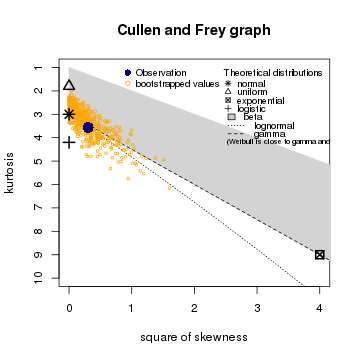

```r
## summary statistics
## ------
## min:  16.62   max:  54.15
## median:  40.38
## mean:  40.28434
## estimated sd:  7.420034
## estimated skewness:  -0.551717
## estimated kurtosis:  3.565162
```

```r
fit.weibull <- fitdist(x, "weibull")
fit.norm <- fitdist(x, "norm")
```

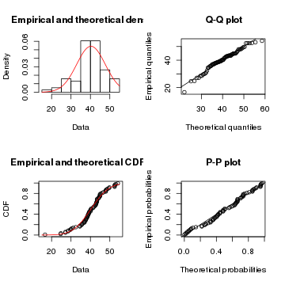

```r
plot(fit.norm)
```

```r
fit.norm$aic
```

```r
## [1] 523.3079
```

As explained here, we can use bootstrapping to add pointwise confidence intervals to the estimated Weibull PDF or CDF:

```r
xs <- seq(10, 65, len=500)

true.weibull <- rweibull(1e6, shape= fit.weibull$estimate["shape"]
                             , scale = fit.weibull$estimate["scale"])

boot.pdf <- sapply(1:1000, function(i) {
  xi <- sample(x, size=length(x), replace=TRUE)
  MLE.est <- suppressWarnings(fitdist(xi, distr="weibull"))
  dweibull(xs, shape=MLE.est$estimate["shape"],  scale = MLE.est$estimate["scale"])
}
)

boot.cdf <- sapply(1:1000, function(i) {
  xi <- sample(x, size=length(x), replace=TRUE)
  MLE.est <- suppressWarnings(fitdist(xi, distr="weibull"))
  pweibull(xs, shape= MLE.est$estimate["shape"],  scale = MLE.est$estimate["scale"])
}
)
```

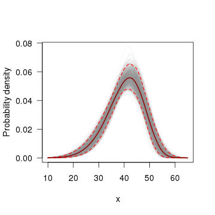

```r
#-----------------------------------------------------------------------------
# Plot PDF
#-----------------------------------------------------------------------------

par(bg="white", las=1, cex=1.2)
plot(xs, boot.pdf[, 1], type="l", col=rgb(.6, .6, .6, .1), ylim=range(boot.pdf),
     xlab="x", ylab="Probability density")
for(i in 2:ncol(boot.pdf)) lines(xs, boot.pdf[, i], col=rgb(.6, .6, .6, .1))

# Add pointwise confidence bands

quants <- apply(boot.pdf, 1, quantile, c(0.025, 0.5, 0.975))
min.point <- apply(boot.pdf, 1, min, na.rm=TRUE)
max.point <- apply(boot.pdf, 1, max, na.rm=TRUE)
lines(xs, quants[1, ], col="red", lwd=1.5, lty=2)
lines(xs, quants[3, ], col="red", lwd=1.5, lty=2)
lines(xs, quants[2, ], col="darkred", lwd=2)
```

# sparkline example

```r
x = rnorm(20)
library(sparkline)
sparkline(x)
```

[interactive chart not shown]

```r
sparkline(x, type = 'bar')
```

[interactive chart not shown]

```r
sparkline(x, type = 'box')
```

[interactive chart not shown]

# Inline line graphs

[interactive chart not shown]

Bar charts

[interactive chart not shown]

negative values:

[interactive chart not shown]

# table

```r
y <- runif(20)
```

| Stock | Sparkline | Boxplot |
| --- | --- | --- |
| x |  |  |

[output not shown]

[interactive chart not shown]

[output not shown]

[interactive chart not shown]

[output not shown]

[interactive chart not shown]

# Reproducibility

This final section highlights how this vignette was created.

## To recreate this vignette

This vignette was generated using:

Additional semantic markup can be added the the citations themselves, such as the reason for the citation. https://github.com/trinker/knitcitations

- `knitrBootstrap`
- Running behind the scenes:
  - `knitr` (Xie, 2014)
  - `rmarkdown` (Allaire, McPherson, Xie, Wickham, Cheng, and Allen, 2014)
  - Cite an R package using the 'bibentry' object (Temple Lang, 2014).

## YAML boiler plate

```r
str(rmarkdown::metadata) # https://github.com/rstudio/rmarkdown/issues/260
```

```r
## List of 8
##  $ yamlFileName: chr "2015-01-11-minimal.Rmd"
##  $ title       : chr "Minimal"
##  $ type        : chr "posts"
##  $ layout      : chr "post"
##  $ tags        : chr [1:2] "Rminimal" "sparklineminimal plotminimal"
##  $ categories  : chr "rstatsminimal sparklineminimal"
##  $ output      :List of 1
##   ..$ knitrBootstrap::bootstrap_document:List of 5
##   .. ..$ theme            : chr "Cyborg"
##   .. ..$ theme.chooser    : logi TRUE
##   .. ..$ highlight        : chr "monokai"
##   .. ..$ highlight.chooser: logi TRUE
##   .. ..$ menu             : logi TRUE
##  $ author      : chr "ttmmghmm"
```

## `R` information

### Session and packages

```r
##  setting  value
##  version  R version 3.1.2 (2014-10-31)
##  system   x86_64, linux-gnu
##  ui       X11
##  language (EN)
##  collate  C
##  tz
```

```r
##  package        * version  date       source
##  RCurl            1.95.4.5 2014-12-28 CRAN (R 3.1.2)
##  RJSONIO          1.3.0    2014-07-28 CRAN (R 3.1.2)
##  Rcpp             0.11.3   2014-09-29 CRAN (R 3.1.2)
##  RefManageR       0.8.40   2014-10-29 CRAN (R 3.1.2)
##  XML              3.98.1.1 2013-06-20 CRAN (R 3.1.2)
##  bibtex           0.4.0    2014-12-31 CRAN (R 3.1.2)
##  bitops           1.0.6    2013-08-17 CRAN (R 3.1.2)
##  devtools       * 1.6.1    2014-10-07 CRAN (R 3.1.2)
##  digest           0.6.8    2014-12-31 CRAN (R 3.1.2)
##  evaluate         0.5.5    2014-04-29 CRAN (R 3.1.2)
##  fitdistrplus   * 1.0.3    2014-12-13 CRAN (R 3.1.2)
##  formatR          1.0      2014-08-25 CRAN (R 3.1.2)
##  htmltools        0.2.6    2014-09-08 CRAN (R 3.1.2)
##  htmlwidgets      0.3.2    2014-12-09 CRAN (R 3.1.2)
##  httr             0.6.1    2015-01-01 CRAN (R 3.1.2)
##  knitcitations  * 1.0.5    2014-11-26 CRAN (R 3.1.2)
##  knitr          * 1.8.13   2015-01-01 local
##  knitrBootstrap   1.0.0    2015-01-01 Github (jimhester/knitrBootstrap@76c41f0)
##  logspline      * 2.1.5    2013-04-24 CRAN (R 3.1.2)
##  lubridate        1.3.3    2013-12-31 CRAN (R 3.1.2)
##  magrittr       * 1.5      2014-11-22 CRAN (R 3.1.2)
##  markdown         0.7.4    2014-08-24 CRAN (R 3.1.2)
##  memoise          0.2.1    2014-04-22 CRAN (R 3.1.2)
##  mime             0.2      2014-09-26 CRAN (R 3.1.2)
##  plyr             1.8.1    2014-02-26 CRAN (R 3.1.2)
##  rmarkdown        0.4.2    2015-01-01 Github (rstudio/rmarkdown@ddeb876)
##  rstudioapi       0.2      2014-12-31 CRAN (R 3.1.2)
##  sparkline      * 1.0      2015-01-10 Github (htmlwidgets/sparkline@aefe3a1)
##  stringr          0.6.2    2012-12-06 CRAN (R 3.1.2)
##  survival         2.37.7   2014-01-22 CRAN (R 3.0.2)
##  yaml             2.1.13   2014-06-12 CRAN (R 3.1.2)
```

### Runtime

Vignette generated in 20.1 seconds.

Timestamp 2015-01-11 20:43:33.

# Bibliography

Citations made with `knitcitations` (Boettiger, 2014).

[1] J. Allaire, J. McPherson, Y. Xie, et al. *rmarkdown: Dynamic Documents for R*. R package version 0.4.2. 2014. .

[2] C. Boettiger. *knitcitations: Citations for knitr markdown files*. R package version 1.0.5. 2014. .

[3] J. Hester. *knitrBootstrap: Knitr Bootstrap framework.* R package version 1.0.0. 2014. .

[4] D. Temple Lang. *RCurl: General network (HTTP/FTP/...) client interface for R*. R package version 1.95-4.5. 2014. .

[5] Y. Xie. "knitr: A Comprehensive Tool for Reproducible Research in R". In: *Implementing Reproducible Computational Research*. Ed. by V. Stodden, F. Leisch and R. D. Peng. ISBN 978-1466561595. Chapman and Hall/CRC, 2014. .

Styled with knitrBootstrap